# Bayesian Model Averaging, Default Priors & Prediction Accuracy

# Exploratory Data Analysis

This exploratory data analysis (EDA) is comprised of two parts: (1) the univariate analysis which examines the frequencies and proportions of categorical variables and the centrality, variability, spread and shape of the distributions of quantitative variables, and (2) the bivariate analysis which explores the relationships between the independent variables and audience scores.

## Univariate Analysis

### Qualitative Analysis

#### Summary Variables

Figure 1, shows the counts and percentages for three *summary* variables: the drama, the feature film, and the MPAA R rating indicator variables. The drama genre comprises nearly half of the films in the sample. Ra rated films constitute a slight plurality and nearly all films surveyed were indeed feature films.

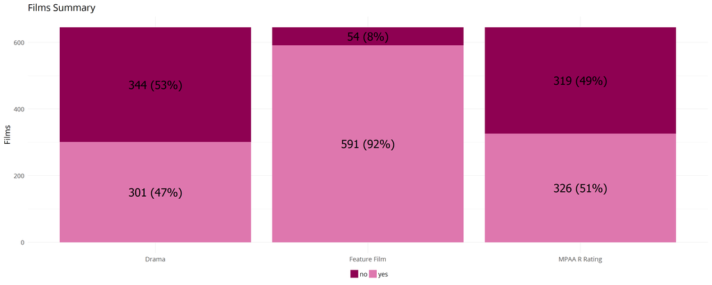

Figure 1: Drama, features and R Rated Films

#### Film Performance Variables

Next, indicators of film performance are examined. Figure 2 summarizes the counts and proportions of films in the sample which have achieved notability at the box office or at the Academy. Best Picture receipients constitute the top one percent, literally. Approximately 2% of the films were in the top 200 club and some three percent were nominated for best picture. Films earning best director, best actress, and best actor Oscars were slightly less rarefied at 7%, 11%, and 14% of the sample respectively.

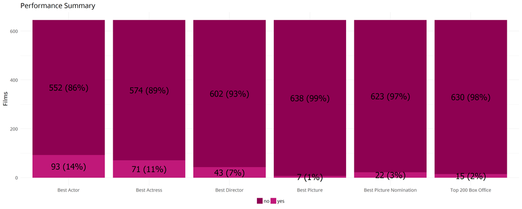

Figure 2: Oscar Awards and Top Box Office

#### Theatrical Release Season

The Oscar season, starting in October and lasting until 31 December, marks the period in which Hollywood studios release their more critically acclaimed films. As indicated in Figure 3, approximately 30% of films in the data set were released during the Oscar season.

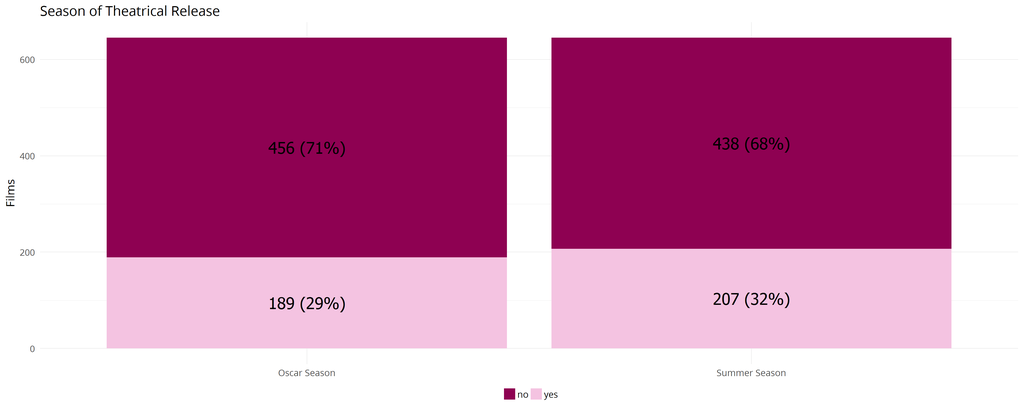

The summer season, which starts the first weekend of May and ends on Labour Day, accounts for disproportionate share of Hollywood studio’s annual box office revenue. Similarly, some 32% of the feature films in the data set were launched during the summer months.

#### Year of Theatrical Release

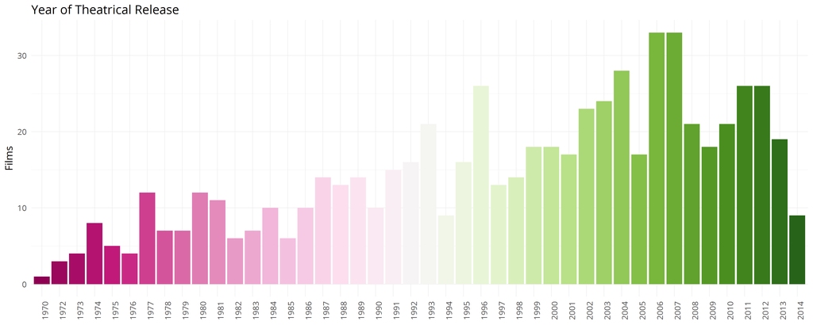

Figure 5: Theatrical Releases by Year

### Quantitative Analysis

#### Critics Score

Moving on to the quantitative variables, the critics score, ranging from 1 to 100, was obtained from the Rotten Tomatoes website and its summary statistics are described below in Table 1.

Table 1: Critics score summary statistics

| N | Min | Q1 | Median | Mean | Q3 | IQR | Max | NA.s | SD | CV | Kurtosis | Skewness | Outliers |
| --- | --- | --- | --- | --- | --- | --- | --- | --- | --- | --- | --- | --- | --- |
| 645 | 1 | 33 | 61 | 57.6 | 83 | 50 | 100 | 0 | 28.4 | 49.3 | -1.18 | -0.27 | 0 |

The distribution of critics scores represented in Figure 6 and further supported by Figure 7 departs rather substantitively from normality. That said, bayesian inference does not rely upon an assumption of normality with respect to the distribution of predictors.

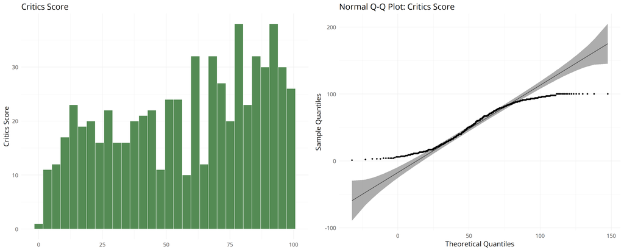

Figure 6: Critics score histogram and QQ Plot

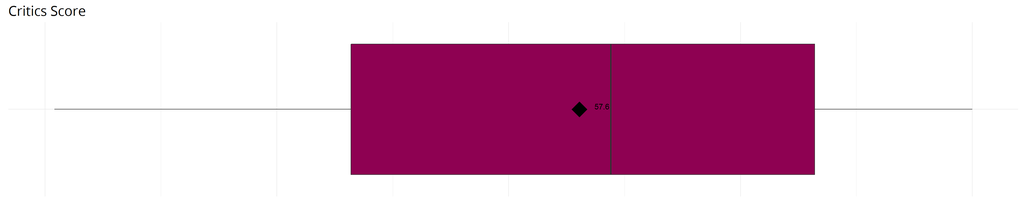

Figure 7: Critics score boxplot

**Central Tendency**: Table 1 reports that the central tendency for critics score was 61 points and 57.6 points for the median and mean, respectively.

**Dispersion**: The standard deviation, s = 28.4, corresponds with a coefficient of variation of 49.3%, indicating a moderate degree of dispersion.

**Shape of Distribution**: The sample skewness (-0.27), indicated that the distribution of critics score was approximately symmetric. The sample kurtosis (-1.18), indicated that the distribution of critics score was platykurtic or light-tailed. The histogram and QQ plot in Figure 6 reveals a left skewed distribution that departs from normality. Fortunately, bayesian inference is not based upon an assumption of normality of predictors.

**Outliers**: The boxplot in Figure 7, which graphically depicts the median, the IQR, and maximum and minimum values, suggested that no outliers were extant. The 25%, 75%, and IQR were 33, 83, and 50, respectively. This yielded a 1.5xIQR ‘acceptable’ range [-42, 158]. Indeed, this confirmed the existence of no outliers. A case-wise review of the influential points revealed no data quality errors. As such, the influential points would be retained for further analysis.

#### IMDb Number of Votes

This variable, obtained from the IMDb website represents the number of IMDb votes cast for each film.

Table 2: IMDb votes summary statistics

| N | Min | Q1 | Median | Mean | Q3 | IQR | Max | NA.s | SD | CV | Kurtosis | Skewness | Outliers |
| --- | --- | --- | --- | --- | --- | --- | --- | --- | --- | --- | --- | --- | --- |
| 645 | 180 | 4821 | 15449 | 58029.3 | 58907 | 54086 | 893008 | 0 | 112526.1 | 193.9 | 19.96 | 4.04 | 68 |

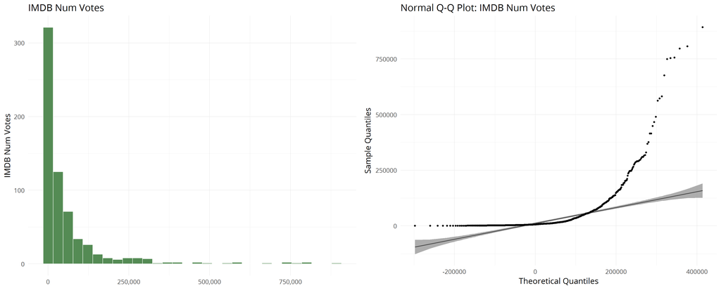

Figure 8: IMDb votes histogram and QQ Plot

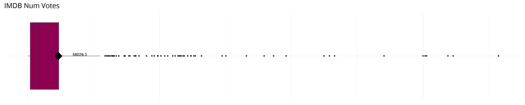

Figure 9: IMDb votes boxplot

**Central Tendency**: The summary statistics (Table 2) show that the central tendency for imdb num votes was 15,449 votes and 58,029.3 votes for the median and mean, respectively.

**Dispersion**: The standard deviation, s = 112,526.11, corresponds with a coefficient of variation of 193.9%, indicating a very high degree of dispersion.

**Shape of Distribution**: The sample skewness (4.04), indicated that the distribution of imdb num votes was right-skewed. The sample kurtosis (19.96), indicated that the distribution of imdb num votes was leptokurtic or heavy-tailed. The histogram and QQ plot in Figure 8 reveal a distribution which departs significantly from normality.

**Outliers**: The boxplot in Figure 9, which graphically depicts the median, the IQR, and maximum and minimum values, suggested that outliers were extant. The 25%, 75%, and IQR were 4,821, 58,907, and 54,086, respectively. This yielded a 1.5xIQR ‘acceptable’ range [-76,308, 140,036]. Indeed, this confirmed the existence of 68 outliers. A case-wise review of the influential points revealed no data quality errors. As such, the influential points would be retained for further analysis.

#### IMDb Number of Votes (Log)

This was a log transformation of the IMDb votes variable.

Table 3: Log IMDb votes summary statistics

| N | Min | Q1 | Median | Mean | Q3 | IQR | Max | NA.s | SD | CV | Kurtosis | Skewness | Outliers |
| --- | --- | --- | --- | --- | --- | --- | --- | --- | --- | --- | --- | --- | --- |
| 645 | 7.5 | 12.2 | 13.9 | 14 | 15.8 | 3.6 | 19.8 | 0 | 2.41 | 17.2 | -0.5 | -0.01 | 0 |

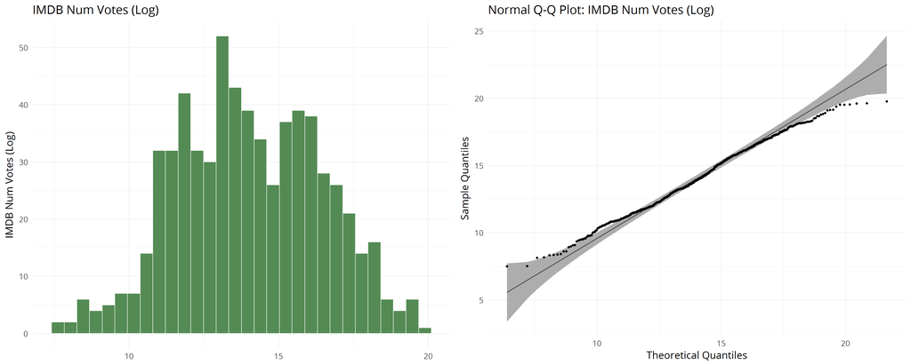

Figure 10: Log IMDb votes histogram and QQ Plot

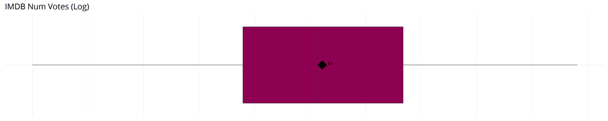

Figure 11: Log IMDb votes boxplot

**Central Tendency**: The summary statistics (Table 3) report that the central tendency for imdb num votes (log) was 13.9 votes and 14 votes for the median and mean, respectively.

**Dispersion**: The standard deviation, s = 2.41, corresponds with a coefficient of variation of 17.2%, indicating a low degree of dispersion.

**Shape of Distribution**: The sample skewness (-0.01), indicated that the distribution of imdb num votes (log) was approximately symmetric. The sample kurtosis (-0.5), indicated that the distribution of imdb num votes (log) was platykurtic or light-tailed. The histogram and QQ plot in Figure 10 reveal a nearly normal distribution.

**Outliers**: The boxplot in Figure 11, which graphically depicts the median, the IQR, and maximum and minimum values, suggested that no outliers were extant. The 25%, 75%, and IQR were 12.2, 15.8, and 3.6, respectively. This yielded a 1.5xIQR ‘acceptable’ range [6.8, 21.2]. Indeed, this confirmed the existence of no outliers. A case-wise review of the influential points revealed no data quality errors. As such, the influential points would be retained for further analysis.

#### IMDb Ratings

This variable captured the IMDb rating for each film

Table 4: IMDb rating summary statistics

| N | Min | Q1 | Median | Mean | Q3 | IQR | Max | NA.s | SD | CV | Kurtosis | Skewness | Outliers |
| --- | --- | --- | --- | --- | --- | --- | --- | --- | --- | --- | --- | --- | --- |
| 645 | 1.9 | 5.9 | 6.6 | 6.5 | 7.3 | 1.4 | 9 | 0 | 1.08 | 16.6 | 1.32 | -0.9 | 19 |

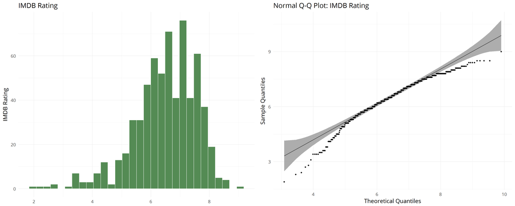

Figure 12: IMDb rating histogram and QQ Plot

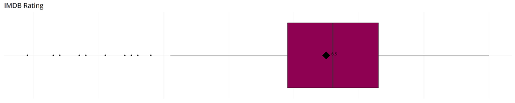

Figure 13: IMDb rating boxplot

**Central Tendency**: The summary statistics (Table 4) shows that the central tendency for imdb rating was 6.6 points and 6.5 points for the median and mean, respectively.

**Dispersion**: The standard deviation, s = 1.08, corresponds with a coefficient of variation of 16.6%, indicating a low degree of dispersion.

**Shape of Distribution**: The sample skewness (-0.9), indicated that the distribution of imdb rating was left-skewed. The sample kurtosis (1.32), indicated that the distribution of imdb rating was leptokurtic or heavy-tailed. The histogram and QQ plot in Figure 12 reveal a nearly normal distribution.

**Outliers**: The boxplot in Figure 13, which graphically depicts the median, the IQR, and maximum and minimum values, suggested that outliers were extant. The 25%, 75%, and IQR were 5.9, 7.3, and 1.4, respectively. This yielded a 1.5xIQR ‘acceptable’ range [3.8, 9.4]. Indeed, this confirmed the existence of 19 outliers. A case-wise review of the influential points revealed no data quality errors. As such, the influential points would be retained for further analysis.

#### Runtime

This is an analysis of moving runtimes.

Table 5: Runtime summary statistics

| N | Min | Q1 | Median | Mean | Q3 | IQR | Max | NA.s | SD | CV | Kurtosis | Skewness | Outliers |
| --- | --- | --- | --- | --- | --- | --- | --- | --- | --- | --- | --- | --- | --- |
| 645 | 39 | 92 | 103 | 105.9 | 116 | 24 | 267 | 0 | 19.49 | 18.4 | 8.99 | 1.75 | 17 |

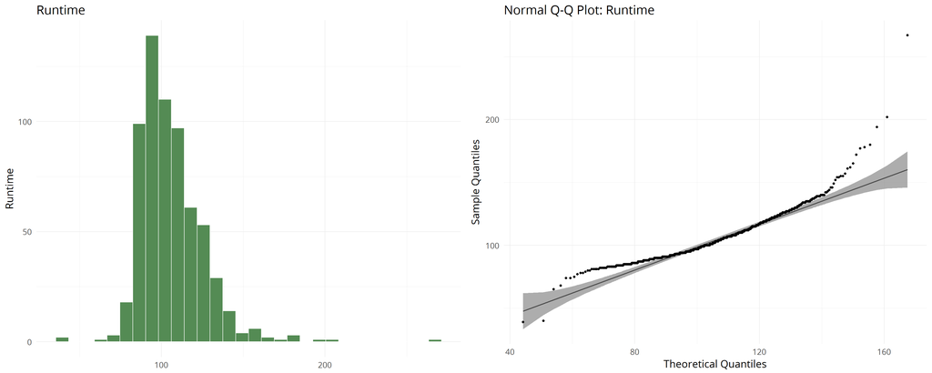

Figure 14: Runtime histogram and QQ Plot

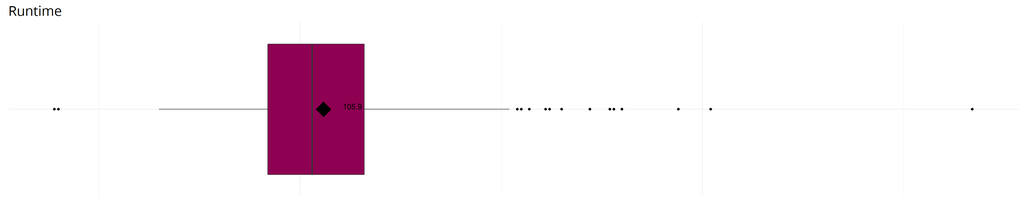

Figure 15: Runtime boxplot

**Central Tendency**: The summary statistics (Table 5) show that the central tendency for runtime was 103 minutes and 105.9 minutes for the median and mean, respectively.

**Dispersion**: The standard deviation, s = 19.49, corresponds with a coefficient of variation of 18.4%, indicating a low degree of dispersion.

**Outliers**: The boxplot in Figure 15, which graphically depicts the median, the IQR, and maximum and minimum values, suggested that outliers were extant. The 25%, 75%, and IQR were 92, 116, and 24, respectively. This yielded a 1.5xIQR ‘acceptable’ range [56, 152]. Indeed, this confirmed the existence of 17 outliers. A case-wise review of the influential points revealed no data quality errors. As such, the influential points would be retained for further analysis.

#### Audience Score

At last, the dependent variable, “audience_score” is examined.

Table 6: Audience Score Summary Statistics

| N | Min | Q1 | Median | Mean | Q3 | IQR | Max | NA.s | SD | CV | Kurtosis | Skewness | Outliers |
| --- | --- | --- | --- | --- | --- | --- | --- | --- | --- | --- | --- | --- | --- |
| 645 | 11 | 46 | 65 | 62.4 | 80 | 34 | 97 | 0 | 20.13 | 32.3 | -0.9 | -0.35 | 0 |

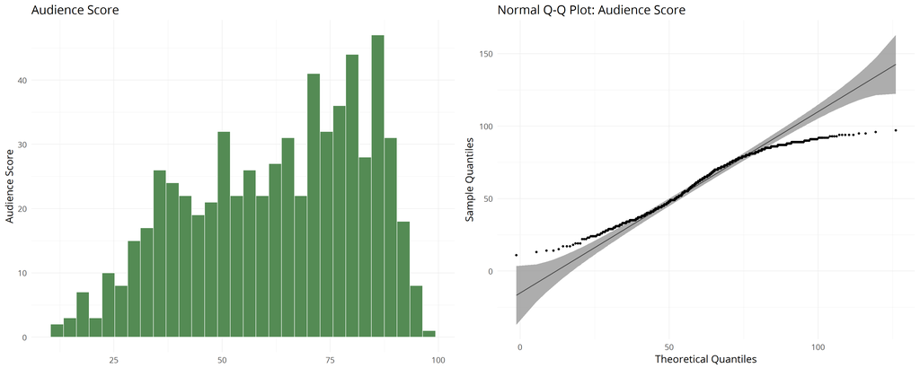

Figure 16: Audience Score Histogram and QQ Plot

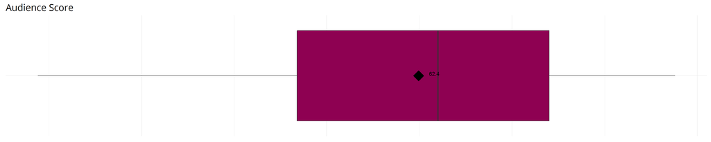

Figure 17: Audience Score Boxplot

**Central Tendency**: The summary statistics (Table 6) shows that the central tendency for audience score was 65 points and 62.4 points for the median and mean, respectively.

**Dispersion**: The standard deviation, s = 20.13, corresponds with a coefficient of variation of 32.3%, indicating a moderate degree of dispersion.

## Bivariate Analysis

Next, the relationships between the independent variables and audience scores are studied. The analysis continues with an exploration of the categorical variables vis-a-vis audience score, then an examination of the quantitative variables and the dependent variable.

### Qualitative Analysis

#### Best Actor Oscar

The summary statistics in Table 7 evince very similar distributions of audience scores between those films which have won the best actor Oscar and those that had not.

Table 7: Audience Scores by Best Actor Oscar Win Summary Statistics

| x | Min | Max | Median | Mean | IQR | SD | N |
| --- | --- | --- | --- | --- | --- | --- | --- |
| no | 13 | 96 | 65 | 62.2 | 34 | 20.2 | 552 |
| yes | 11 | 97 | 64 | 63.3 | 33 | 19.8 | 93 |

The boxplot shown in Figure 18 supports an initial impression that best actor Oscar winnings have no statistically significant association with audience scores.

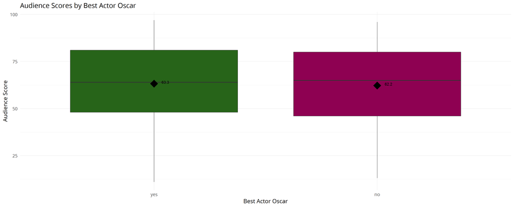

Figure 18: Audience Scores by Best Actor Oscar Win

A one-way ANOVA was conducted to compare the effect of best actor oscar on average audience scores. The effect was non significant at the p<.05 level [F(1,643) = 0, p = 0.654] As such, the data does not support an association between best actor Oscar award and audience score.

#### Best Actress Oscar

Similarly, the summary statistics in Table 8 reveal almost identical distributions for audience score for both groups.

Table 8: Audience Scores by Best Actress Oscar Win Summary Statistics

| x | Min | Max | Median | Mean | IQR | SD | N |
| --- | --- | --- | --- | --- | --- | --- | --- |
| no | 11 | 96 | 65 | 62.2 | 34.0 | 20.2 | 574 |
| yes | 14 | 97 | 69 | 63.7 | 30.5 | 19.5 | 71 |

Again, the boxplot shown in Figure 19 graphically supports an assertion of little to no association between best actress Oscar winning and audience scores.

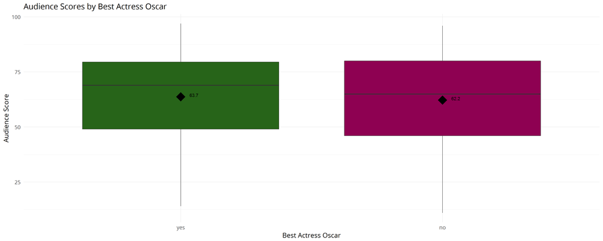

Figure 19: Audience Scores by Best Actress Oscar Win

A one-way ANOVA was conducted to compare the effect of best actress oscar on average audience scores. The effect was non significant at the p<.05 level [F(1,643) = 0, p = 0.556]

#### Best Director Oscar

The summary statistics shown in Table 9 suggest that films which have been awarded the best director Oscar are also associated with higher average audience scores.

Table 9: Audience Scores by Best Director Oscar Win Summary Statistics

| x | Min | Max | Median | Mean | IQR | SD | N |
| --- | --- | --- | --- | --- | --- | --- | --- |
| no | 11 | 96 | 65 | 61.9 | 33.75 | 20.1 | 602 |
| yes | 27 | 97 | 73 | 69.5 | 32.50 | 19.0 | 43 |

The box plot in Figure 20 reveals a slighly higher center for audience scores among those films with best director acclaim.

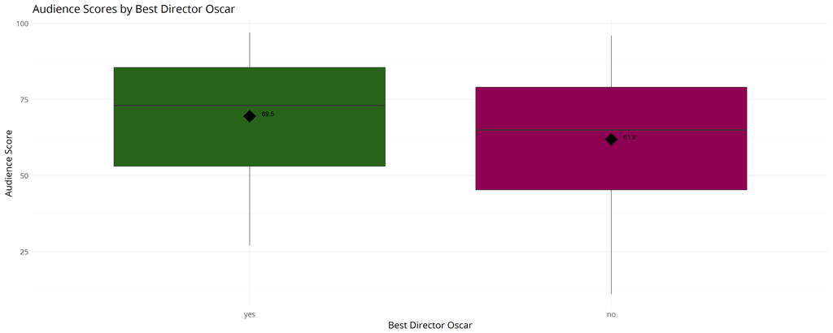

Figure 20: Audience Scores by Best Director Oscar Win

#### Best Picture Nomination

The association between Oscar performance and audience scores becomes extant for the first time with the best picture nomination. The summary statistics shown in Table 10 reveal a sizeable difference in average and median audience scores between the films so nominated and those that were not.

Table 10: Audience Scores by Best Picture Nomination Summary Statistics

| x | Min | Max | Median | Mean | IQR | SD | N |
| --- | --- | --- | --- | --- | --- | --- | --- |
| no | 11 | 96 | 64.0 | 61.6 | 33.5 | 20.0 | 623 |
| yes | 69 | 97 | 86.5 | 85.3 | 9.5 | 7.7 | 22 |

The box plot in Figure 21 supports a priori hypothesis that best picture nominations are associated with higher audience scores.

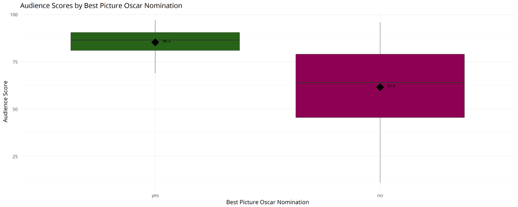

Figure 21: Audience Scores by Best Picture Nomination

A one-way ANOVA was conducted to compare the effect of best picture oscar nomination on average audience scores. The effect was significant at the p<.05 level [F(1,643) = 31, p = 0] Indeed the data support an association between best picture nomination and audience scores.

#### Best Picture Oscar

As one my expect, given prior results, the summary statistics shown in Table 11 suggests an association between Oscar best picture acclaim and higher audience scores.

Table 11: Audience Scores by Best Picture Oscar Summary Statistics

| x | Min | Max | Median | Mean | IQR | SD | N |
| --- | --- | --- | --- | --- | --- | --- | --- |
| no | 11 | 96 | 65 | 62.1 | 33.0 | 20.1 | 638 |
| yes | 69 | 97 | 84 | 84.7 | 7.5 | 9.0 | 7 |

Similarly, the box plot in Figure 22 clarifies the potential association between Oscar performance and audience scores.

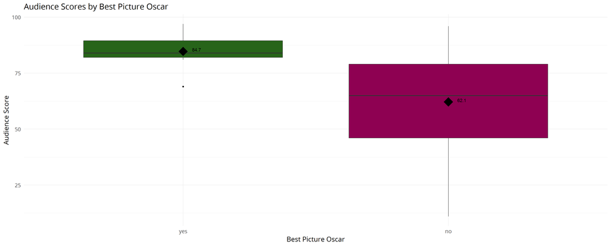

Figure 22: Audience Scores by Best Picture Oscar

A one-way ANOVA was conducted to compare the effect of best picture oscar on average audience scores. The effect was significant at the p<.05 level [F(1,643) = 9, p = 0.003] Surely, the data do in fact support an association between best picture award and audience scores.

#### Drama

The summary statistics in Table 12 report a slight difference in the central audience scores between dramas and non-drama films.

Table 12: Audience Scores by Genre Summary Statistics

| x | Min | Max | Median | Mean | IQR | SD | N |
| --- | --- | --- | --- | --- | --- | --- | --- |
| no | 11 | 97 | 61 | 59.8 | 38 | 21.2 | 344 |
| yes | 13 | 95 | 70 | 65.3 | 28 | 18.4 | 301 |

The box plot in Figure 23 also shows a slight tendancy towards higher audience scores for dramas, but it significant?

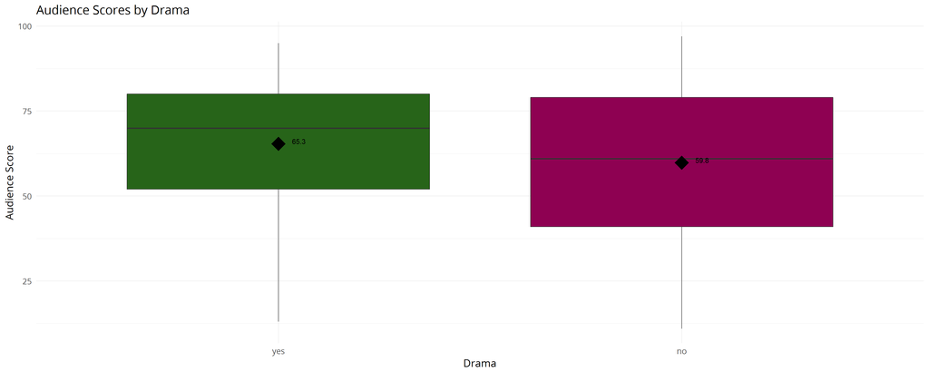

Figure 23: Audience Scores by Genre

A one-way ANOVA was conducted to compare the effect of drama on average audience scores. The effect was significant at the p<.05 level [F(1,643) = 12, p = 0] Dramas are indeed, associated with slighly higher audience scores.

#### Features Films

The summary statistics in Table 13 expose a rather sizeable difference in audience scores between feature films and other film types. In fact, feature films appear to be associated with significantly lower average audience scores.

Table 13: Audience Scores by Film Type Summary Statistics

| x | Min | Max | Median | Mean | IQR | SD | N |
| --- | --- | --- | --- | --- | --- | --- | --- |
| no | 68 | 96 | 86 | 83.5 | 11.0 | 7.5 | 54 |
| yes | 11 | 97 | 62 | 60.5 | 33.5 | 19.8 | 591 |

The box plot in Figure 24 visually characterizes the difference in the distribution of audience scores between the film types.

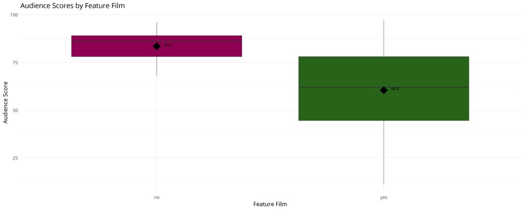

Figure 24: Audience Scores by Film Type

A one-way ANOVA was conducted to compare the effect of feature film on average audience scores. The effect was significant at the p<.05 level [F(1,643) = 72, p = 0] The data shows that non feature films are associated with higher audience scores.

#### Rated R

The summary statistics in Table 14 suggest very similar distributions of audience scores between rated R and other films.

Table 14: Audience Scores by MPAA Rating Summary Statistics

| x | Min | Max | Median | Mean | IQR | SD | N |
| --- | --- | --- | --- | --- | --- | --- | --- |
| no | 11 | 96 | 65 | 62.8 | 31.50 | 20.2 | 319 |
| yes | 14 | 97 | 64 | 62.0 | 34.75 | 20.0 | 326 |

The box plot in Figure 25 shows a slighly lower central audience score for R rated films.

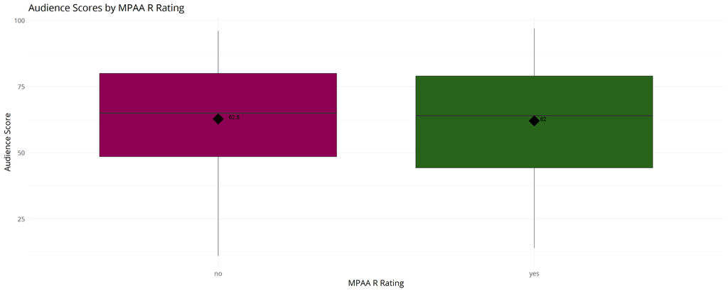

Figure 25: Audience Scores by MPAA Rating

A one-way ANOVA was conducted to compare the effect of mpaa r rating on average audience scores. The effect was non significant at the p<.05 level [F(1,643) = 0, p = 0.646] As such the data do not support an association between audience scores and MPAA R ratings.

#### Oscar Season Release

Again, the summary statistics in Table 15 report nearly identical distributions of audience scores between films released during the Oscar season and those that were not.

Table 15: Audience Scores and Oscar Season Release Summary Statistics

| x | Min | Max | Median | Mean | IQR | SD | N |
| --- | --- | --- | --- | --- | --- | --- | --- |
| no | 11 | 96 | 64 | 61.8 | 33 | 20.0 | 456 |
| yes | 13 | 97 | 69 | 63.9 | 33 | 20.3 | 189 |

The box plot in Figure 26 echo the summary statistics.

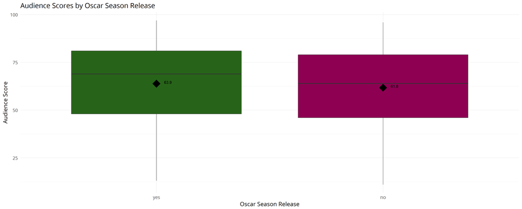

Figure 26: Audience Scores and Oscar Season Release

A one-way ANOVA was conducted to compare the effect of oscar season release on average audience scores. The effect was non significant at the p<.05 level [F(1,643) = 1, p = 0.231] As such the data do not support an association between audience scores and Oscar season release dates.

#### Summer Season Release

Similarly, the summary statistics in Table 16 report nearly identical distributions of audience scores between films released during the summer season and those that were not.

Table 16: Audience Scores and Summer Season Release Summary Statistics

[output not shown]

The box plot in Figure 27 backs the summary statistics.

[figure not shown]

Figure 27: Audience Scores and Summer Season Release

#### Top 200 Box Office

As one might conjecture, the top 200 box office films might be associated with higher audience scores, almost be definition. This is indicated by the summary statistics in Table 17 which show significantly higher central audience scores for the highest grossing films.

| x | Min | Max | Median | Mean | IQR | SD | N |
| --- | --- | --- | --- | --- | --- | --- | --- |
| no | 11 | 97 | 65 | 62.1 | 33.0 | 20.1 | 630 |
| yes | 34 | 92 | 81 | 74.5 | 12.5 | 16.6 | 15 |

The box plot in Figure 28 illuminates this difference.

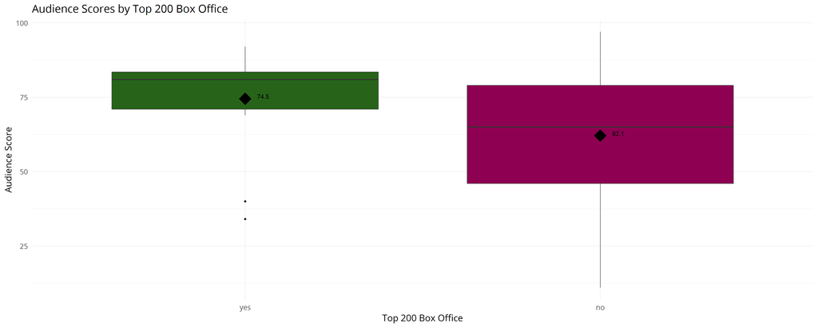

### Quantitative Analysis

#### Critics Score

The scatterplot (Figure 29) indicates a positive correlation between critics score and audience score.

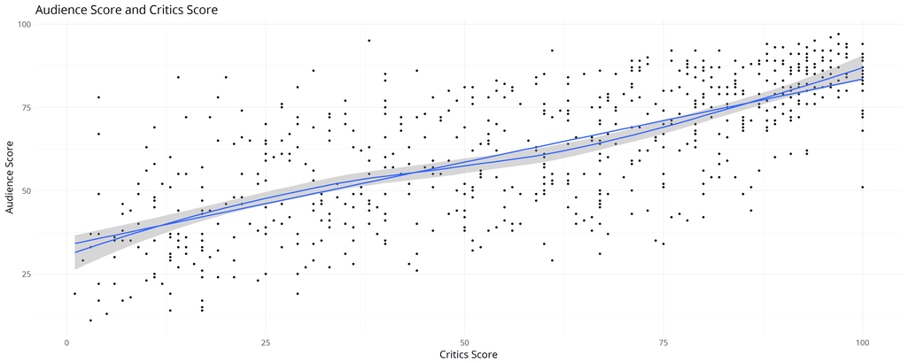

Figure 29: Audience Score and Critics Score

A Pearson product-moment correlation coefficient was computed to assess the relationship between critics score and audience scores. There was a positive correlation between the two variables, r = 0.703 n = 643 p = 0. As supported by the scatterplot, a strong positive correlation between critics score and audience score was extant

#### IMDB Num Votes

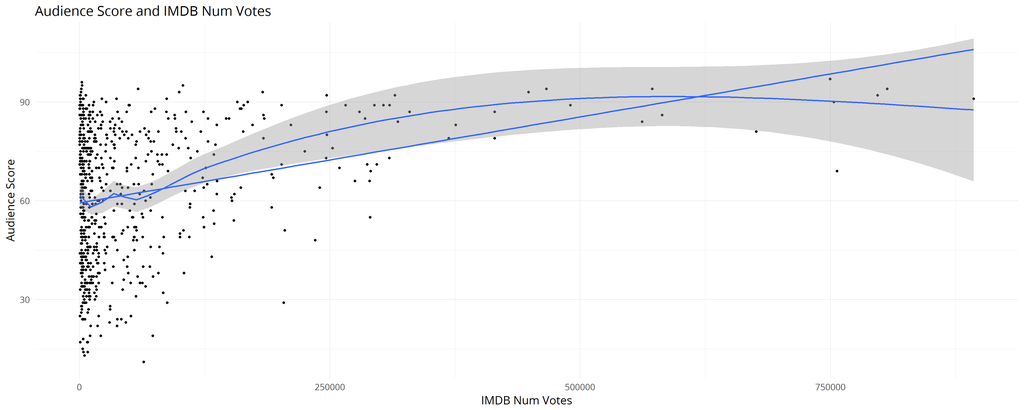

Figure 30: Audience Score and IMDB Num Votes

A Pearson product-moment correlation coefficient was computed to assess the relationship between imdb num votes and audience scores. There was a positive correlation between the two variables, r = 0.292 n = 643 p = 0. As supported by the scatterplot, a weak positive correlation between imdb num votes and audience score was extant

#### IMDB Num Votes (Log)

The scatterplot (Figure 31) reveals a slight positive correlation between the log of IMDB number of votes and audience score.

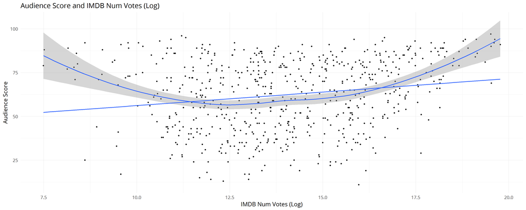

Figure 31: Audience Score and IMDB Number of Votes (Log)

A Pearson product-moment correlation coefficient was computed to assess the relationship between imdb num votes (log) and audience scores. There was a positive correlation between the two variables, r = 0.185 n = 643 p = 0. As supported by the scatterplot, a weak positive correlation between imdb num votes (log) and audience score was observed